# 10. Análisis de la expresión génica

## Objetivos

1. Origen de los datos.
2. Sesgos comunes.
3. Estrategias de análisis.
4. Algo de terminología.

# Cuantificación de la expresión

## RNA-seq

1. Extracción del mRNA del tejido.
2. Generación de cDNA.
3. Fragmentación y selección de tamaños.
4. Adición de adaptadores.
5. Secuenciación.

## Lecturas y nivel de expresión

- $\tau_i$: Fracción de tránscritos que provienen de un gen o isoforma.
- $\nu_i$: Fracción de nucleótidos que provienen de un gen o isoforma.
- $l_i$: Longitud de los tránscritos que provienen de una isoforma.
- $c_i$: Número de lecturas procedentes de una isoforma. $N=\sum_ic_i$.

$$\lim_{N\to\infty}\left(\frac{c_i}{N}\right) = \nu_i$$

## Lecturas y nivel de expresión

Cuanto mayor es la expresión (y el tamaño) de una isoforma, mayor número de lecturas producirá. El problema es que no todas las lecturas pueden asignarse a una isoforma sin ambigüedad. Hace falta *estimar* el nivel de expresión, por ejemplo con RSEM (B. Li et al. 2010).

## Alineamiento al genoma anotado

El programa debe facilitar los gaps que corresponden a intrones:

- [HISAT2](https://daehwankimlab.github.io/hisat2/) (Kim et al. 2019)
- STAR (Dobin et al. 2013)

Después hay que usar [bedtools intersect](https://bedtools.readthedocs.io/en/latest/content/tools/intersect.html) o [featureCounts](https://subread.sourceforge.net/featureCounts.html) con los alineamientos (BAM) y la anotación (GTF) para **contar** cuantas lecturas mapean sobre cada tránscrito.

## Alineamiento a los tránscritos

- Necesitas secuencias FASTA de los tránscritos (o cDNAs): [Ensemble?](https://www.ensembl.org)
- Cualquier alineador de lecturas cortas servirá: `bwa-mem2`, `bowtie2`, etc.
- Después hay que **contar** cuantas lecturas mapean en cada tránscrito:
  - RSEM

## Pseudo-alineamiento

Para mayor rapidez: buscan palabras coincidentes para estimar el tránscrito de origen de cada lectura:

- [Salmon](https://github.com/COMBINE-lab/salmon)
- kallisto

Producen directamente **recuentos** de cada tránscrito para cada muestra.

# Análisis de expresión diferencial

## El problema

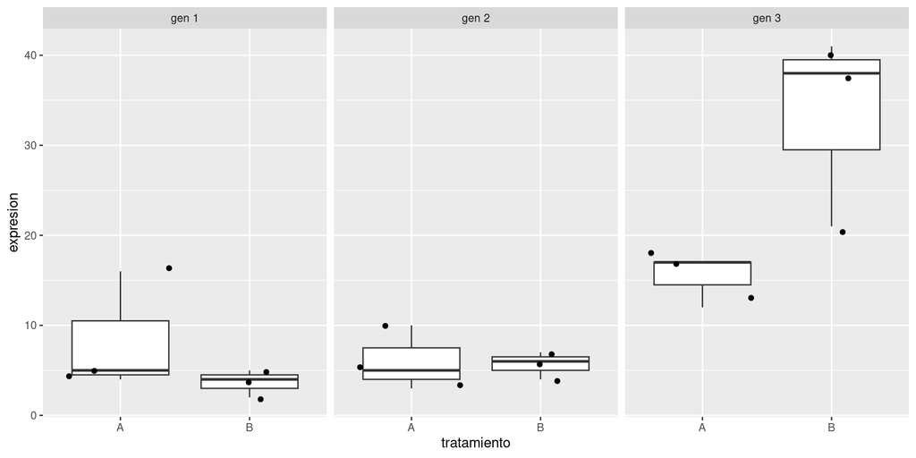

- Muchos genes: tests múltiples.
- Pocas réplicas: tests poco poderosos.

## El problema

Número de lecturas de la muestra $j$ asignadas al gen $i$ puede describirse con una distribución **binomial negativa**:

$$K_{ij} \sim \mathrm{NB}(\mu_{ij}, \sigma_{ij}^2)$$

que tiene **dos** parámetros: demasiados para estimarlos con precisión en cada muestra y cada gen (pocas réplicas).

## Estrategia

Todos los métodos comparten información entre genes para estimar las $\sigma_{ij}^2$. Suponemos que genes con un nivel de expresión ($\mu_{ij}$) parecido también tendrán varianzas parecidas.

## Principales paquetes

- **limma**: No usa la NB, sino que usa el logaritmo del recuento normalizado (log-CPM) en un modelo lineal. Aplica *empirical Bayes* (EB) para reducir la dispersión.
- **edgeR**: Asume la distribución NB y también aplica EB. Asume:
  $$\sigma_{ij}^2 = \mu_{ij} + \phi_i\mu_{ij}^2$$
- **DESeq2**: Parecido a edgeR, con un modelo más sofisticado de la varianza. El más recomendable para muestras de tamaño 6 o mayores (D. Li et al. 2022).
- **EBSeq**: Incorpora incertidumbre en el recuento de lecturas debido a distinguir la expresión de isoformas del mismo gen. El más recomendado cuando hay pocas (3-5) réplicas por grupo (D. Li et al. 2022).

## Normalización

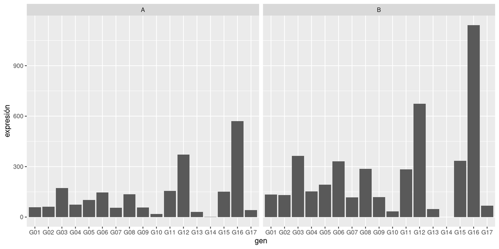

El modelo ya tiene en cuenta que las muestras más intensamente secuenciadas, tienen recuentos más elevados. **No** hay que normalizar, sino calcular el *factor de normalización*.

## TMM

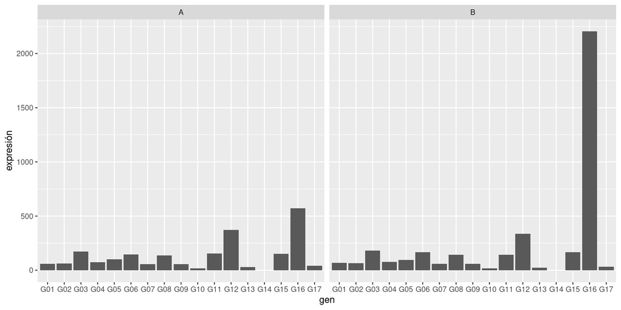

TMM (*trimmed mean of M-values*) calcula un factor de corrección para cada muestra que corrige los desequilibrios extremos entre genes. En la figura, la muestra B tiene el doble de lecturas que la A. Pero el tamaño *efectivo* de la genoteca de B debe ser disminuido para que la mayor parte de genes no parezcan diferencialmente expresados.

## Referencias

Dobin, Alexander, Carrie A. Davis, Felix Schlesinger, Jorg Drenkow, Chris Zaleski, Sonali Jha, Philippe Batut, Mark Chaisson, and Thomas R. Gingeras. 2013. “STAR: Ultrafast Universal RNA-Seq Aligner.” *Bioinformatics* 29 (1): 15–21. https://doi.org/10.1093/bioinformatics/bts635.

Kim, D., J. M. Paggi, C. Park, C. Bennett, and S. L. Salzberg. 2019. “Graph-Based Genome Alignment and Genotyping with HISAT2 and HISAT-Genotype.” *Nature Biotechnology* 37: 907–15. https://doi.org/10.1038/s41587-019-0201-4.

Li, Bo, Victor Ruotti, Ron M. Stewart, James A. Thomson, and Colin N. Dewey. 2010. “RNA-Seq Gene Expression Estimation with Read Mapping Uncertainty.” *Bioinformatics* 26 (4): 493–500. https://doi.org/10.1093/bioinformatics/btp692.

Li, D., M. S. Zand, T. D. Dye, M. L. Goniewicz, I. Rahman, and Z. Xie. 2022. “An Evaluation of RNA-Seq Differential Analysis Methods.” *PLOS ONE* 17 (9): 1–19. https://doi.org/10.1371/journal.pone.0264246.